# Class 6

Tobias Gerstenberg

January 16th, 2026

# 6 Probability

## 6.1 Load packages, load data, set theme

Let’s load the packages that we need for this chapter.

```r
library("knitr")        # for rendering the RMarkdown file
library("kableExtra")   # for nicely formatted tables
library("arrangements") # fast generators and iterators for creating combinations
library("DiagrammeR")   # for drawing diagrams
library("tidyverse")    # for data wrangling
```

Set the plotting theme.

```r
theme_set(theme_classic() +
            theme(text = element_text(size = 20)))

opts_chunk$set(comment = "",
               fig.show = "hold")
```

## 6.2 Counting

Imagine that there are three balls in an urn. The balls are labeled 1, 2, and 3. Let’s consider a few possible situations.

```r
balls = 1:3 # number of balls in urn
ndraws = 2 # number of draws

# order matters, without replacement
permutations(balls, ndraws)
```

```
     [,1] [,2]
[1,]    1    2
[2,]    1    3
[3,]    2    1
[4,]    2    3
[5,]    3    1
[6,]    3    2
```

```r
# order matters, with replacement
permutations(balls, ndraws, replace = T)
```

```
      [,1] [,2]
 [1,]    1    1
 [2,]    1    2
 [3,]    1    3
 [4,]    2    1
 [5,]    2    2
 [6,]    2    3
 [7,]    3    1
 [8,]    3    2
 [9,]    3    3
```

```r
# order doesn't matter, with replacement
combinations(balls, ndraws, replace = T)
```

```
     [,1] [,2]
[1,]    1    1
[2,]    1    2
[3,]    1    3
[4,]    2    2
[5,]    2    3
[6,]    3    3
```

```r
# order doesn't matter, without replacement
combinations(balls, ndraws)
```

```
     [,1] [,2]
[1,]    1    2
[2,]    1    3
[3,]    2    3
```

I’ve generated the figures below using the `DiagrammeR` package. It’s a powerful package for drawing diagrams in R. See information on how to use the DiagrammeR package [here](https://rich-iannone.github.io/DiagrammeR/).

[interactive chart not shown]

Figure 6.1: Drawing two marbles out of an urn **with** replacement.

[interactive chart not shown]

Figure 6.2: Drawing two marbles out of an urn **without** replacement.

## 6.3 The random secretary

A secretary types four letters to four people and addresses the four envelopes. If he inserts the letters at random, each in a different envelope, what is the probability that exactly three letters will go into the right envelope?

```r
df.letters = permutations(x = 1:4, k = 4) %>%
  as_tibble(.name_repair = ~ str_c("person_", 1:4)) %>%
  mutate(n_correct = (person_1 == 1) +
           (person_2 == 2) +
           (person_3 == 3) +
           (person_4 == 4))

df.letters %>%
  summarize(prob_3_correct = sum(n_correct == 3) / n())
```

```
# A tibble: 1 × 1
  prob_3_correct
           <dbl>
1              0
```

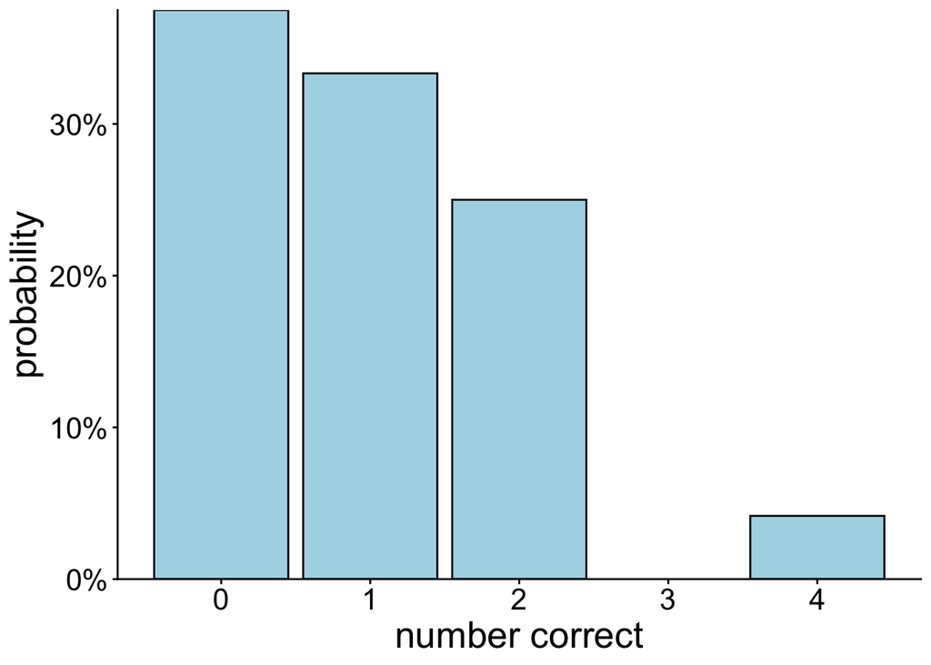

```r
ggplot(data = df.letters,
       mapping = aes(x = n_correct)) +
  geom_bar(aes(y = after_stat(count)/sum(count)),
           color = "black",
           fill = "lightblue") +
  scale_y_continuous(labels = scales::percent,
                     expand = c(0, 0)) +
  labs(x = "number correct",
       y = "probability")
```

## 6.4 Flipping a coin many times

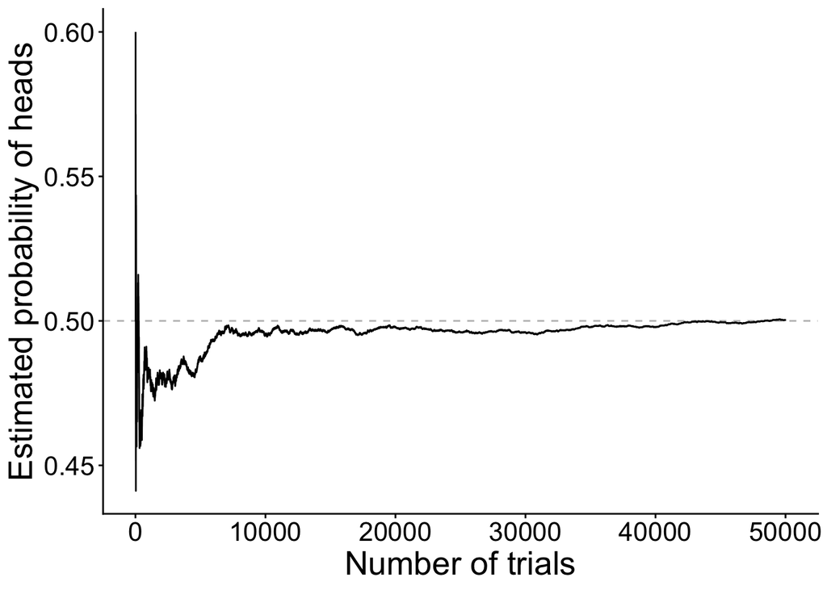

Figure 6.3: A demonstration of the law of large numbers.

```r
# Example taken from here: http://statsthinking21.org/probability.html#empirical-frequency

set.seed(1) # set the seed so that the outcome is consistent
nsamples = 50000 # how many flips do we want to make?

# create some random coin flips using the rbinom() function with
# a true probability of 0.5

df.samples = tibble(trial_number = seq(nsamples),
                    outcomes = rbinom(nsamples, 1, 0.5)) %>%
  mutate(mean_probability = cumsum(outcomes) / seq_along(outcomes)) %>%
  filter(trial_number >= 10) # start with a minimum sample of 10 flips

ggplot(data = df.samples,
       mapping = aes(x = trial_number, y = mean_probability)) +
  geom_hline(yintercept = 0.5, color = "gray", linetype = "dashed") +
  geom_line() +
  labs(x = "Number of trials",
       y = "Estimated probability of heads") +
  theme_classic() +
  theme(text = element_text(size = 20))
```

## 6.5 Clue guide to probability

```r
who = c("ms_scarlet", "col_mustard", "mrs_white",
        "mr_green", "mrs_peacock", "prof_plum")
what = c("candlestick", "knife", "lead_pipe",
         "revolver", "rope", "wrench")
where = c("study", "kitchen", "conservatory",
          "lounge", "billiard_room", "hall",
          "dining_room", "ballroom", "library")

df.clue = expand_grid(who = who,
                      what = what,
                      where = where)

#How many possible combinations?
#count number of rows in df.clue
nrow(df.clue)
```

```
[1] 324
```

```r
df.suspects = df.clue %>%
  distinct(who) %>%
  mutate(gender = ifelse(test = who %in% c("ms_scarlet", "mrs_white", "mrs_peacock"),
                         yes = "female",
                         no = "male"))
```

```r
df.suspects %>%
  arrange(desc(gender)) %>%
  kable() %>%
  kable_styling("striped", full_width = F)
```

| who | gender |
| --- | --- |
| col_mustard | male |
| mr_green | male |
| prof_plum | male |
| ms_scarlet | female |
| mrs_white | female |
| mrs_peacock | female |

### 6.5.1 Conditional probability

```r
# conditional probability (via rules of probability)
df.suspects %>%
  summarize(p_prof_plum_given_male =
              sum(gender == "male" & who == "prof_plum") /
              sum(gender == "male"))
```

```
# A tibble: 1 × 1
  p_prof_plum_given_male
                   <dbl>
1                  0.333
```

```r
# conditional probability (via rejection)
df.suspects %>%
  filter(gender == "male") %>%
  summarize(p_prof_plum_given_male =
              sum(who == "prof_plum") /
              n())
```

```
# A tibble: 1 × 1
  p_prof_plum_given_male
                   <dbl>
1                  0.333
```

### 6.5.2 Law of total probability

[interactive chart not shown]

## 6.6 Probability operations

```r
# Make a deck of cards
df.cards = tibble(suit = rep(c("Clubs", "Spades", "Hearts", "Diamonds"), each = 8),
                  value = rep(c("7", "8", "9", "10", "Jack", "Queen", "King", "Ace"), 4))
```

```r
# conditional probability: p(Hearts | Queen) (via rules of probability)
df.cards %>%
  summarize(p_hearts_given_queen =
              sum(suit == "Hearts" & value == "Queen") /
              sum(value == "Queen"))
```

```
# A tibble: 1 × 1
  p_hearts_given_queen
                 <dbl>
1                 0.25
```

```r
# conditional probability: p(Hearts | Queen) (via rejection)
df.cards %>%
  filter(value == "Queen") %>%
  summarize(p_hearts_given_queen = sum(suit == "Hearts")/n())
```

```
# A tibble: 1 × 1
  p_hearts_given_queen
                 <dbl>
1                 0.25
```

## 6.7 Bayesian reasoning explained

[interactive chart not shown]

## 6.8 Getting Bayes right matters

### 6.8.1 Bayesian reasoning example

```r
# prior probability of the disease
p.D = 0.01

# sensitivity of the test
p.T_given_D = 0.95

# specificity of the test
p.notT_given_notD = 0.95
p.T_given_notD = (1 - p.notT_given_notD)

# posterior given a positive test result
p.D_given_T = (p.T_given_D * p.D) / ((p.T_given_D * p.D) + (p.T_given_notD * (1-p.D)))

p.D_given_T
```

```
[1] 0.1610169
```

### 6.8.2 Bayesian reasoning example (COVID rapid test)

https://pubmed.ncbi.nlm.nih.gov/34242764/#:~:text=The%20overall%20sensitivity%20of%20the,%25%20CI%2024.4%2D65.1).

```r
# prior probability of the disease
p.D = 0.1

# sensitivity covid rapid test
p.T_given_D = 0.653

# specificity of covid rapid test
p.notT_given_notD = 0.999

p.T_given_notD = (1 - p.notT_given_notD)

# posterior given a positive test result
p.D_given_T = (p.T_given_D * p.D) / ((p.T_given_D * p.D) + (p.T_given_notD * (1-p.D)))

# posterior given a negative test result
p.D_given_notT = ((1-p.T_given_D) * p.D) / (((1-p.T_given_D) * p.D) + ((1-p.T_given_notD) * (1-p.D)))

str_c("Probability of COVID given a positive test: ", round(p.D_given_T * 100, 1), "%")
```

```
[1] "Probability of COVID given a positive test: 98.6%"
```

```r
str_c("Probability of COVID given a negative test: ", round(p.D_given_notT * 100, 1), "%")
```

```
[1] "Probability of COVID given a negative test: 3.7%"
```

### 6.8.3 Most people in the hospital are vaccinated

```r
# probability of being vaccinated
p.V = 0.8

# likelihood of hospital
p.H_given_V = 0.2
p.H_given_notV = 0.5

# posterior probability
p.V_given_H = (p.H_given_V * p.V) / ((p.H_given_V * p.V) + (p.H_given_notV * (1-p.V)))

p.V_given_H
```

```
[1] 0.6153846
```

## 6.9 Building a Bayesis

### 6.9.1 Dice example

```r
# prior
p.four = 0.5
p.six = 0.5

# possibilities
df.possibilities = tibble(observation = 1:6,
                          p.four = c(rep(1/4, 4), rep(0, 2)),
                          p.six = c(rep(1/6, 6)))

# data
# data = c(4)
# data = c(4, 2, 1)
data = c(4, 2, 1, 3, 1)
# data = c(4, 2, 1, 3, 1, 5)

# likelihood
p.data_given_four = prod(df.possibilities$p.four[data])
p.data_given_six = prod(df.possibilities$p.six[data])

# posterior
p.four_given_data = (p.data_given_four * p.four) /
  ((p.data_given_four * p.four) +
     (p.data_given_six * p.six))

p.four_given_data
```

```
[1] 0.8836364
```

Given this data $d$ = [4, 2, 1, 3, 1], there is a 88% chance that the four sided die was rolled rather than the six sided die.

## 6.10 Additional resources

### 6.10.1 Cheatsheets

- Probability cheatsheet

### 6.10.2 Books and chapters

- [Probability and Statistics with examples using R](http://www.isibang.ac.in/~athreya/psweur/)
- [Learning statistics with R: Chapter 9 Introduction to probability](https://learningstatisticswithr-bookdown.netlify.com/probability.html#probstats)

### 6.10.3 Misc

- [Bayes’ theorem in three panels](https://www.tjmahr.com/bayes-theorem-in-three-panels/)
- [Statistics 110: Probability; course at Harvard](https://projects.iq.harvard.edu/stat110)
- [Bayes theorem and making probability intuitive](https://www.youtube.com/watch?v=HZGCoVF3YvM&feature=youtu.be)

## 6.11 Session info